# Graph Theory

Miguel Miní

05/24/2020

## ¿Qué es teoría de grafos?

Supongamos que queremos ubicar una calle en específico, o saber si un organismo forma un cluster con otro tipo de organismo en una muestra, que pasa si necesitamos ir de la forma más rápida de un punto a otro en una ciudad, o si queremos detener el avance de un ejercito con la menor cantidad de soldados posibles.

todos estos problemas pueden y necesitan un modelo para ser resueltos más fácilmente. Con estás ideas, unas menos y otras más, la teoría de grafos fue naciendo, con ayuda de Kőnig, Euler, Erdős, Kuhn, Ford, Fukerson, Bellman, FLoyd, Dikjstra, Kruskal, entre otros. Tomando mucha acogida en optimización combinatoria, algebra, biologia, hasta en la misma guerra.

Antes de todo, ¿Qué es un grafo?

### ¿Qué es un grafo?

Un grafo es un dibujo.

[figure not shown]

Pero, no todo dibujo se puede dibujar en un papel, aquellos que sí se llamarán grafos planares. Algunos solo se podrán dibujar en una tasa con muchas asas, tal vez lo hayas oido [antes](https://en.wikipedia.org/wiki/Homeomorphism).

En el mayor de los casos un grafo se verá así:

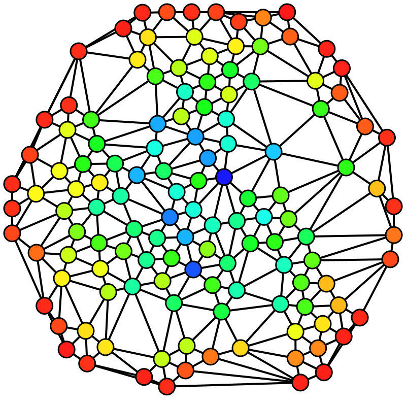

Podemos apreciar que un grafo tiene dos elementos que serán comunes desde ahora:

- **Nodos**: aquellos circulos que estan conectados por medio de rayas.
- **Aristas**: aquellas conexiones (rayas) entre los nodos.

### ¿Cuantas aristas tiene un grafo con $n$ nodos?

Supongamos que entramos a una fiesta, donde hay $n$ personas (nodos), y le preguntamos a cada una de ellas cuantos amigos tiene (conexiones?) que también están en la fiesta. ¿Qué valores puede tener la suma de todas esas cantidades para cada persona?

**respuesta**

desde $0$ hasta $n (n-1)$

Ahora, en nuestro problema, las aristas serían las relaciones de amistad de dos personas, esto quiere decir que si la primera persona es amigo de la quinta (y la quinta de la primera) solo se cuenta como una arista, ¿cuantas aristas tiene este “grafo”? (rango)

**respuesta**

desde $0$ hasta $\frac{n (n-1)}{2}$

pero a todo esto…

### ¿Cómo guardo un grafo en computadora?

si nos vamos al ejemplo anterior, lo único que yo deseo saber es si la persona $i$ y $j$ están conectadas, entonces me bastaría con que luzca así:

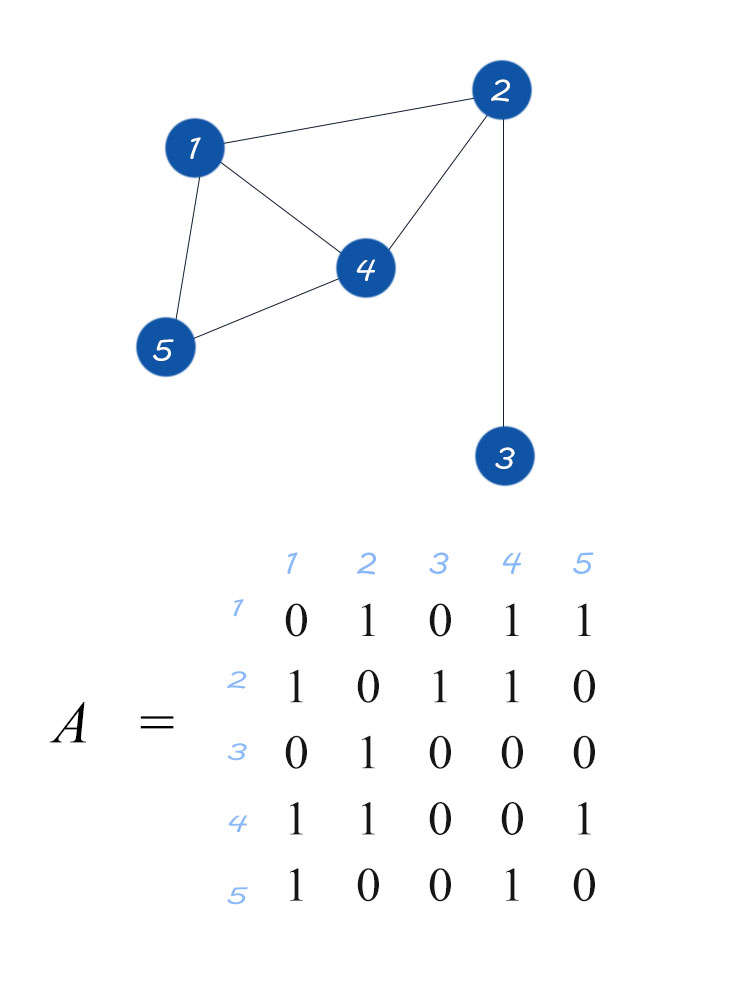

```cpp
#include <bit/stdc++.h>
using namespace std;
const int maxn = 1001; //si me dan a lo mas 1000 nodos.
bool A[maxn][maxn];

int main() {
  int n, m; //número de nodos, número de aristas
  cin >> n >> m;
  for (int i = 1; i <= m; ++i) {
    int a, b;
    cin >> a >> b;
    A[a][b] = A[b][a] = 1;
  }
  for (int i = 1; i <= n; ++i) {
    for (int j = 1; j <= n; ++j) {
      cout << A[i][j] << " ";
    }
    cout << endl;
  }
  return 0;
}
```

Pero, pronto veremos que no todo grafo tiene O($n^2$) aristas, hay algunos que siempre tienen $n-1$. En este caso lo que más me conviene para guardarlo sería:

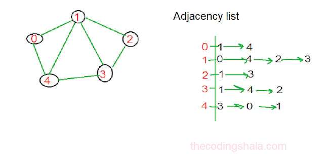

Donde la lista i, tiene los elementos que son adyacentes con el nodo i (los que forman una arista con i)

```cpp
#include <bits/stdc++.h>
using namespace std;
const int maxn = 1001;

vector<int> adj[maxn];

int main() {
  int n, m;
  cin >> n >> m;
  for (int i = 1; i <= m; ++i) {
    int a, b;
    cin >> a >> b;
    adj[a].push_back(b);
    adj[b].push_back(a);
  }
  for (int i = 1; i <= n; ++i) {
    cout << i << ": ";
    for (int v : adj[i]) {
      cout << v << " ";
    }
    cout << endl;
  }
  return 0;
}
```

## ¿Recorrer un grafo? ¿Por qué?

Supongamos que queremos saber si una persona está en la fiesta, para ella le podemos preguntar a uno de nuestros amigos, y el le puede preguntar a sus amigos, ¿Asumiendo que la persona se encuentre, cómo puedo saber si la puedo encontrar?

Este es un clásico problema de recorrer un grafo, al recorrer un grafo puedo saber quienes están conectados y el problema se puede responder sabiendo si dos nodos están conectados.

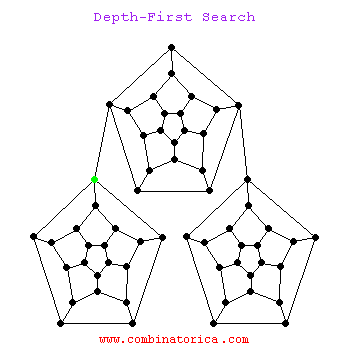

```cpp
#include <bits/stdc++.h>
using namespace std;
const int maxn = 1010;
vector<int> adj[maxn];
bool visited[maxn];

void dfs(int x) { //depth-first search
  visited[x] = 1;
  for (int v : adj[x]) {
    if (not visited[v]) {
      dfs(v);
    }
  }
}

int main() {
  int n, m;
  cin >> n >> m;
  for (int i = 1; i <= m; ++i) {
    int a, b;
    cin >> a >> b;
    adj[a].push_back(b);
    adj[b].push_back(a);
  }
  int s, t; //s y t son los nodos que deben estar conectados
  cin >> s >> t;
  dfs(s);
  if (visited[t]) cout << "yes" << endl;
  else cout << "no" << endl;
  return 0;
}
```

### El número de Erdős

Paul Erdős, el gran y prolífico teorista de grafos, tiene un número inspirado en él, mira el video para una definición:

[figure not shown]

Supongamos que tenemos el grafo de las personas que han colaborado con Erdős, siendo Erdős el nodo $1$, y todos los demás nodos son entre $2$ y $n$ ¿podemos determinar el número de Erdős para cada uno de ellos?

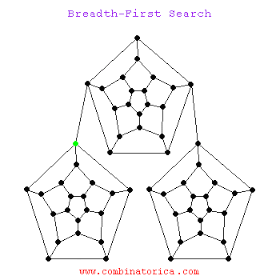

```cpp
#include <bits/stdc++.h>
using namespace std;
const int maxn = 1010;
vector<int> adj[maxn];
bool visited[maxn];
int dist[maxn];

void bfs(int x) { //breadth-first search
  queue<int> Q;
  Q.push(x);
  dist[x] = 0;
  vis[x] = 1;
  while (not Q.empty()) {
    int q = Q.front();
    Q.pop();
    for (int v : adj[q]) {
      if (not vis[v]) {
        vis[v] = 1;
        dist[v] = dist[q] + 1; //calculamos el número de Erdős
        Q.push(v);
      }
    }
  }
}

int main() {
  int n, m;
  cin >> n >> m;
  for (int i = 1; i <= m; ++i) {
    int a, b;
    cin >> a >> b;
    adj[a].push_back(b);
    adj[b].push_back(a);
  }
  bfs(1); //Erdős
  for (int i = 1; i <= n; ++i) {
    cout << dist[i] << " ";
  }
  cout << endl;
  return 0;
}
```

## Referencias

- [csacademy : introduction to graphs](https://csacademy.com/lesson/introduction_to_graphs/)
- [csacademy : graph representation](https://csacademy.com/lesson/graph_representation/)
- [csacademy : depth-first search](https://csacademy.com/lesson/depth_first_search/)
- [breadth-first search](https://csacademy.com/lesson/breadth_first_search/)

## [Problemas de ejemplo](https://www.hackerearth.com/challenges/competitive/code-monk-graph-theory-i/problems/)

## [CONTEST LINK](https://vjudge.net/contest/375388)